# Lecture 15 — Machine Learning for Computer Vision

Lecture 15

Kaveh Fathian

Computer Science Department, Colorado School of Mines

## Learning Objectives

By the end of this lecture, you should be able to:

- Name the main recognition tasks (classification, detection, semantic and instance segmentation) and explain why recognition is hard.
- Describe the data-driven approach, and distinguish supervised, unsupervised, and self-supervised learning.
- Explain underfitting, overfitting, and the bias–variance trade-off, and why more data helps.
- Use training, validation, and test sets to fit parameters, choose hyperparameters, and report a final error.
- Choose an evaluation metric that fits the task, evaluate a classifier with accuracy and the confusion matrix, and explain why accuracy can mislead when classes are imbalanced.
- Represent an image as a feature vector, compare images with the L2 distance, classify them with KNN, and explain the limitations of KNN on raw pixels.
- Cluster data with k-means, and use it to segment an image by color.
- Compute PCA, interpret its components and reconstructions, and use PCA coordinates as compact features.
- Explain linear classifiers, the SVM margin, soft margins, kernels, and multi-class SVMs, and train an SVM with OpenCV.

## Fundamental Equations of Computer Vision

[output not shown]

## Recognition Tasks in Computer Vision

[figure not shown]

- **Classification:** is there a person? $\rightarrow$ one label for the image.
- **Detection:** where is each person? $\rightarrow$ a box per person.
- **Semantic segmentation:** which pixels are “person”? $\rightarrow$ a label per pixel.
- **Instance segmentation:** which pixels belong to which person? $\rightarrow$ a mask per person.
- Others: scene categorization, activity/event recognition, …

## Why Is Recognition Hard?

[figure not shown]

- How many different object classes are there? Roughly 10,000 to 30,000.
- Objects of the same class can have very different pixels.

## The Data-Driven Approach

[figure not shown]

1. **Training set**: Images with ground truth labels.
2. **Learning**: A learning algorithm fits a **model** $f$ to data: $f(\text{image}) \approx \text{label}$.
3. **Inference**: Use $f$ on new images. What matters is how well $f$ does on images it has never seen.

## Types of Learning

[figure not shown]

| Type | Training data | Vision examples |
| --- | --- | --- |
| **Supervised** | images **and** labels | classify clothing; detect pedestrians |
| **Unsupervised** | images only | group pixels by color (clustering); compress images (PCA) |
| **Self-supervised** | images only; the labels come from the data itself | predict hidden patches; match images to their captions |

- Labels cost effort, more so for richer labels: tag < box < mask.

## Common Machine Learning Datasets for Computer Vision

[figure not shown]

| Dataset | Year | Images | Classes | Image size | Task |
| --- | --- | --- | --- | --- | --- |
| MNIST | 1998 | 60,000 train + 10,000 test | 10 digits | 28 × 28, gray | classification |
| FashionMNIST | 2017 | 60,000 train + 10,000 test | 10 clothing types | 28 × 28, gray | classification |
| CIFAR-10 | 2009 | 50,000 train + 10,000 test | 10 objects and animals | 32 × 32, color | classification |
| ImageNet | 2012 | 1.28 M train + 50,000 val | 1,000 | varies, color | classification |
| COCO | 2014 | 118,000 train + 5,000 val | 80 | varies, color | detection, segmentation, captions |
| Penn-Fudan | 2007 | 170 | pedestrians | varies, color | detection, segmentation |

- These are **benchmarks** that are widely used to compare methods on the same data.
- ImageNet’s size made deep learning practical (2012).

## FashionMNIST: Our Running Example

|  | Images | Per class |
| --- | --- | --- |
| Training | 60,000 | 6,000 |
| Test | 10,000 | 1,000 |

- **28 × 28** gray images: 784 pixels, values 0 to 255.
- Same format as MNIST, but harder: T-shirt, pullover, coat, and shirt look alike.
- Small enough to train on a laptop CPU.
- We compare our classifiers on this benchmark.

[figure not shown]

## A Toy Learning Problem

- **Task:** predict $y$ from $x$, using only the noisy points.
- **Model:** a polynomial of degree $M$:

$$\bbox[border: 2px solid #c53030; padding: 2px 6px]{\hat{y} = w_0 + w_1 x + w_2 x^2 + \dots + w_M x^M}\;\;{\color{#c53030}{\begin{array}{l}\textbf{polynomial}\\ \textbf{model}\end{array}}}$$

- $x$: input; $\hat{y}$: prediction
- $w_0, \dots, w_M$: **parameters** learned from the data.
- **Learning:** pick the $w$’s with the smallest **mean squared error** (MSE) on the training points:

$$\text{MSE} = \frac{1}{N} \sum_{i=1}^{N} \left(y_i - \hat{y}_i\right)^2$$

- $y_i$: true value; $\hat{y}_i$: prediction for point $i$; $N$: number of points.

[figure not shown]

## Model Complexity: Underfitting vs. Overfitting

[figure not shown]

- **Underfit:** too simple to follow the pattern $\rightarrow$ high error everywhere.
- **Overfit:** so flexible that it fits the **noise** $\rightarrow$ lowest training error, huge error on new data.
- The goal is **generalization**: low error on data the model has **not** seen. Training error alone does not tell us that.

## Train / Validation / Test

- **Training set:** fit the **parameters** $(w_0, \dots, w_M)$.
- **Validation set:** choose the **hyperparameters**: settings we pick, not learned (here, the degree $M$).
- **Test set:** measure the final error **once**, at the end. Never use it to make choices.

[figure not shown]

## Choosing the Degree

**Choosing a Hyperparameter**

1. For each candidate $M$: fit on the **training** set.
2. Measure the error on the **validation** set.
3. Keep the $M$ with the lowest validation error.
4. Report the **test** error of that model, once.
- Training error keeps falling as $M$ grows. Validation error falls, then rises.
- Best: $M$ = **3** (validation MSE 0.097). Its test MSE: **0.072**.

[figure not shown]

## Bias–Variance Trade-Off

[figure not shown]

- Each thin line: a fit to a **different training set** (same $x$, new noise). Black: their average.
- **Bias:** the average fit misses the truth $\rightarrow$ the model is **too simple**.
- **Variance:** the fit changes a lot from one training set to the next $\rightarrow$ the model is **too flexible**.
- New-data error $\approx$ bias² + variance + noise. The best complexity balances the two.

## More Data Helps

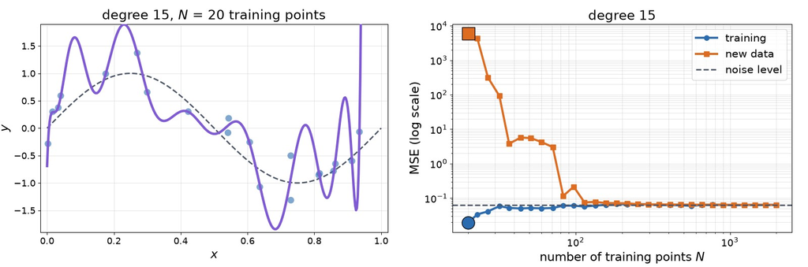

- With few points, the flexible model fits the noise. With many, it **cannot** fit the noise, so it follows the true curve.
- Training and new-data errors meet at the noise level, which no model can beat.
- **More data** is often the best cure for overfitting.

## Polynomial Fitting in Code

- `Polynomial.fit(x, y, deg)`: finds the $w$’s with the smallest training MSE (least squares).
- `model(x)`: evaluates the fitted polynomial at `x`.
- `mse(...)`: the mean squared error from before.
- `min(val_mse, key=val_mse.get)`: the degree with the lowest validation error.

On our data: best $M$ = **3**, test MSE = **0.072**.

[figure not shown]

```python
import numpy as np
from numpy.polynomial import Polynomial

def mse(model, x, y):
    return np.mean((model(x) - y) ** 2)

# (x_tr, y_tr), (x_val, y_val), (x_te, y_te): splits
val_mse = {}
for M in range(16):
    model = Polynomial.fit(x_tr, y_tr, deg=M)
    val_mse[M] = mse(model, x_val, y_val)

best_M = min(val_mse, key=val_mse.get)
model = Polynomial.fit(x_tr, y_tr, deg=best_M)
print(best_M, mse(model, x_te, y_te))   # test: once
```

## Polynomial Fitting: Full Code

```python
import numpy as np
import matplotlib.pyplot as plt
from numpy.polynomial import Polynomial

# 1. Data: noisy samples of y = sin(2 pi x). Split 20 / 10 / 10.
rng = np.random.default_rng(0)
x = rng.uniform(0, 1, 40)
y = np.sin(2 * np.pi * x) + rng.normal(0, 0.25, 40)
x_tr, y_tr = x[:20], y[:20]
x_val, y_val = x[20:30], y[20:30]
x_te, y_te = x[30:], y[30:]

def mse(model, x, y):
    return np.mean((model(x) - y) ** 2)

# 2. Fit every degree on the training set; measure training and validation error.
degrees = range(16)
train_mse, val_mse = [], []
for M in degrees:
    model = Polynomial.fit(x_tr, y_tr, deg=M)
    train_mse.append(mse(model, x_tr, y_tr))
    val_mse.append(mse(model, x_val, y_val))

# 3. Choose the degree on the validation set; report the test error once.
best_M = int(np.argmin(val_mse))
model = Polynomial.fit(x_tr, y_tr, deg=best_M)
print("best degree:", best_M)
print("test MSE:", mse(model, x_te, y_te))

# 4. Plot the errors and the chosen fit.
fig, (ax1, ax2) = plt.subplots(1, 2, figsize=(12, 4.5))
ax1.semilogy(degrees, train_mse, "o-", label="training")
ax1.semilogy(degrees, val_mse, "s-", label="validation")
ax1.set_xlabel("degree")
ax1.set_ylabel("MSE")
ax1.legend()

xs = np.linspace(0, 1, 400)
ax2.scatter(x_tr, y_tr, label="training points")
ax2.plot(xs, model(xs), "g", label=f"degree {best_M} fit")
ax2.plot(xs, np.sin(2 * np.pi * xs), "k--", label="true curve")
ax2.legend()
plt.tight_layout()
plt.savefig("poly_fit.png")
plt.show()
```

## Evaluation Metrics Depend on the Task

[figure not shown]

| Task | Output | Common metrics |
| --- | --- | --- |
| Regression | number(s) | mean squared error (MSE) |
| Classification | a category | accuracy; confusion matrix (which classes get mixed up) |
| Detection | a box and class per object | intersection over union (IoU); precision and recall; average precision (AP) |
| Segmentation | a label per pixel | IoU per class |

## When Accuracy Misleads

[figure not shown]

- 10,000 images, only 1% contain a person. Method **A** finds nobody, yet has a higher accuracy than method **B** that finds most people (99.0% vs. 97.8%).
- Need to look at both precision and recall. **Precision**: fraction of correct detections (A: undefined (no detections), B: 29%). **Recall**: fraction of people found (A: 0%, B: 80%).
- Accuracy is fine when the classes are **balanced** (as in FashionMNIST).

# Supervised Learning: KNN

## An Image Is a Vector

- A 28 × 28 gray image is **784 numbers**. Stack its rows into one long vector $\mathbf{x} = (x_1, x_2, \dots, x_{784})$.
- Compare two images pixel by pixel:

$$\bbox[border: 2px solid #c53030; padding: 2px 6px]{d(\mathbf{x}, \mathbf{x}') = \sqrt{\sum_{j=1}^{784} \left(x_j - x'_j\right)^2}}\;\;{\color{#c53030}{\begin{array}{l}\textbf{L2}\\ \textbf{distance}\end{array}}}$$

- $x_j$, $x'_j$: value of pixel $j$ (0 to 1) in images $\mathbf{x}$ and $\mathbf{x}'$.
- Small $d$: similar images. Large $d$: different images.
- The sneaker is closest to the other sneaker ($d$ = 6.7) and farthest from the trouser ($d$ = 11.9).

[figure not shown]

## Examples of Nearest Neighbors on FashionMNIST

- **Query** (left column): a test image.
- **Neighbors:** the 5 training images with the smallest L2 distance to the query, from NN1 (closest) to NN5.
- Green frame: same class as the query. Red frame: a different class.
- Mistakes come from look-alike classes: the shirt has T-shirt and pullover neighbors, and the dress has coat neighbors.
- The sandal’s closest neighbor is a sneaker, but 3 of its 5 neighbors are sandals.
- Simple idea: **classify a new image based on the majority class among its $k$ nearest neighbors.**

[figure not shown]

## k-Nearest Neighbors (KNN) Classification

**k-Nearest Neighbors (KNN)**

**Training:** store all training images and their labels.

**Prediction** for a new image $\mathbf{x}$:

1. Compute the distance from $\mathbf{x}$ to every training image.
2. Find the $k$ closest training images.
3. Predict the most common label among them (**majority vote**).
- 2D points represent images: each point is a vector with 2 numbers instead of 784.
- **Small $k$:** one noisy neighbor decides.
- **Large $k$:** far-away points join, and the big class wins.

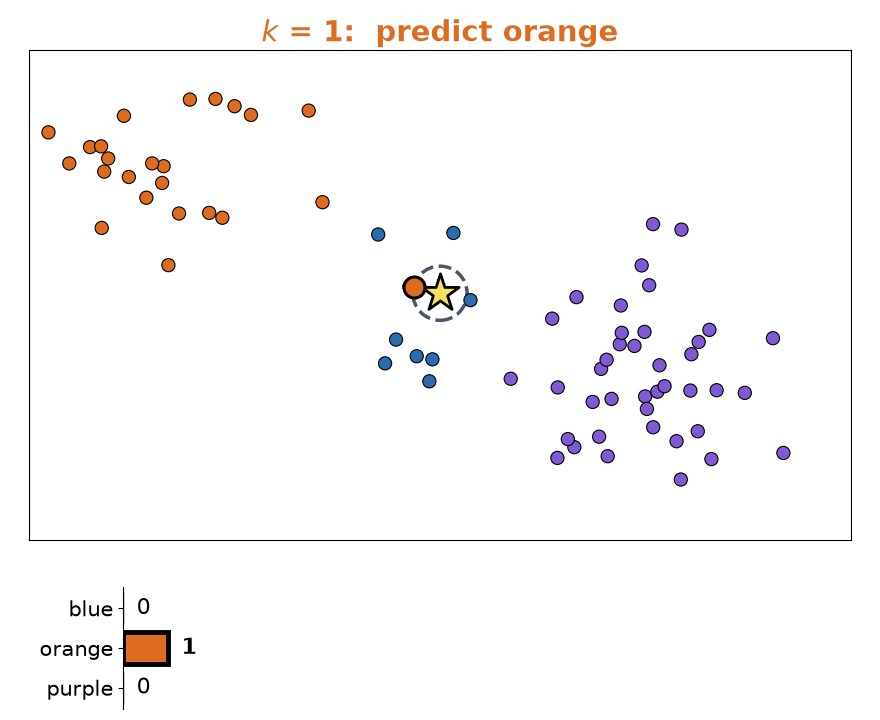

## Decision Boundaries Change with k

[figure not shown]

- **Decision boundary:** where the predicted class changes. Each location is colored by its KNN prediction.
- **Small $k$:** jagged boundary with islands around single points. It fits the noise (**overfitting**).
- **Large $k$:** smooth boundary, but the arms of the spiral get washed out (**underfitting**).
- $k$ is a **hyperparameter**: choose it on validation data, like the polynomial degree.

## Choosing k on FashionMNIST

- Split the 60,000 training images: **50,000 training** + **10,000 validation**. Keep the 10,000 **test** images aside.
- Same recipe as choosing the polynomial degree: for each $k$ = 1, …, 20, predict the validation images with KNN and measure the accuracy.
- Best: $k$ = **6** (validation accuracy 85.5%).
- Test accuracy with $k$ = 6, measured once: **85.0%**.

[figure not shown]

## KNN in Code

- `KNearest_create()`: an empty KNN model.
- `train(X, cv2.ml.ROW_SAMPLE, y)`: stores the data. `X`: one image per row (`float32`); `y`: the labels.
- `findNearest(X, k)`: KNN prediction for each row of `X`. Returns the predicted labels, the labels of the `k` neighbors, and their distances.
- On our data ($k$ = 6): test accuracy **85.0%**, about **1 ms** per test image.

```python
import cv2
import numpy as np

# X_tr: (50000, 784) float32, y_tr: labels 0-9
# X_te: (10000, 784) float32, y_te: labels 0-9
knn = cv2.ml.KNearest_create()
knn.train(X_tr, cv2.ml.ROW_SAMPLE,
          y_tr.astype(np.float32))

# best_k: chosen on the validation set
_, pred, neighbors, dist = knn.findNearest(
    X_te, k=best_k)
pred = pred.ravel().astype(int)
print("test accuracy:", np.mean(pred == y_te))
```

[figure not shown]

## KNN: Full Code

```python
import gzip
from pathlib import Path

import cv2
import numpy as np
import matplotlib.pyplot as plt

# 1. Data: FashionMNIST as 784-vectors. Split 50,000 training / 10,000 validation; 10,000 test.
data_dir = Path("assets/datasets/fashion_mnist")    # folder with the four .gz files

def read_idx(name, offset):
    with gzip.open(data_dir / name) as f:
        return np.frombuffer(f.read(), np.uint8, offset=offset)

X = read_idx("train-images-idx3-ubyte.gz", 16).reshape(-1, 784).astype(np.float32)
y = read_idx("train-labels-idx1-ubyte.gz", 8).astype(int)
X_te = read_idx("t10k-images-idx3-ubyte.gz", 16).reshape(-1, 784).astype(np.float32)
y_te = read_idx("t10k-labels-idx1-ubyte.gz", 8).astype(int)
X_tr, y_tr, X_val, y_val = X[:50000], y[:50000], X[50000:], y[50000:]

# 2. "Training": store the training images.
knn = cv2.ml.KNearest_create()
knn.train(X_tr, cv2.ml.ROW_SAMPLE, y_tr.astype(np.float32))

# 3. Choose k on the validation set. One search for the 20 nearest neighbors
#    (closest first), then a majority vote among the first k of them.
ks = range(1, 21)
_, _, neighbors, _ = knn.findNearest(X_val, k=max(ks))
neighbors = neighbors.astype(int)
val_acc = []
for k in ks:
    pred = np.array([np.bincount(row[:k], minlength=10).argmax() for row in neighbors])
    val_acc.append(np.mean(pred == y_val))
best_k = ks[int(np.argmax(val_acc))]
print(f"best k = {best_k}, validation accuracy = {max(val_acc):.3f}")

# 4. Test accuracy with the chosen k, once.
_, pred, _, _ = knn.findNearest(X_te, k=best_k)
pred = pred.ravel().astype(int)
print(f"test accuracy = {np.mean(pred == y_te):.3f}")

# 5. Confusion matrix: row = true class, column = predicted class.
confusion = np.zeros((10, 10), int)
np.add.at(confusion, (y_te, pred), 1)
print(confusion)

# 6. Plot the validation curve.
plt.plot(ks, val_acc, "s-")
plt.xlabel("k")
plt.ylabel("validation accuracy")
plt.show()
```

## Confusion Matrix and Accuracy

- **Confusion matrix:** entry (row $i$, column $j$) = number of test images of class $i$ predicted as class $j$.
- **Diagonal:** correct predictions. Off-diagonal: mistakes, and which classes get mixed up.
- $\text{accuracy} = \dfrac{\text{sum of the diagonal}}{\text{sum of all entries}}$
- KNN ($k$ = 6): 8,502 / 10,000 correct = **85.0%**.
- Easiest: Sneaker (97% correct). Hardest: **Shirt** (54%), most often called T-shirt/top (207 times).

[figure not shown]

## Limitations of KNN

- **Slow prediction:** compares each new image with all 50,000 training images (about 1.4 ms per new image on a CPU, for all 50,000 comparisons).
- **Stores all the data:** 50,000 × 784 values = 157 MB. More data: more memory and slower predictions.
- **Pixel distance is not semantic:** a 2-pixel shift is invisible to us, but changes many pixels.
  - The shifted shirt is **9.7** away from the original, but a dress is only **7.8** away.
  - Shifting all test images by 2 pixels drops the accuracy from 85.0% to **67.0%**.
- Next: better features and better classifiers.

[figure not shown]

# Unsupervised Learning: Clustering and PCA

## k-Means Clustering

- **Unsupervised:** points without labels. Goal: group them into $k$ **clusters** of nearby points.
- Each cluster has a **center**. Each point belongs to the nearest center.

**k-Means Clustering**

1. Pick $k$ starting centers (e.g., $k$ random points).
2. **Assign:** each point joins its nearest center.
3. **Update:** move each center to the mean of its points.
4. Repeat 2–3 until the assignments stop changing.
- $k$ is a hyperparameter.
- Different starting centers can lead to different final clusters.

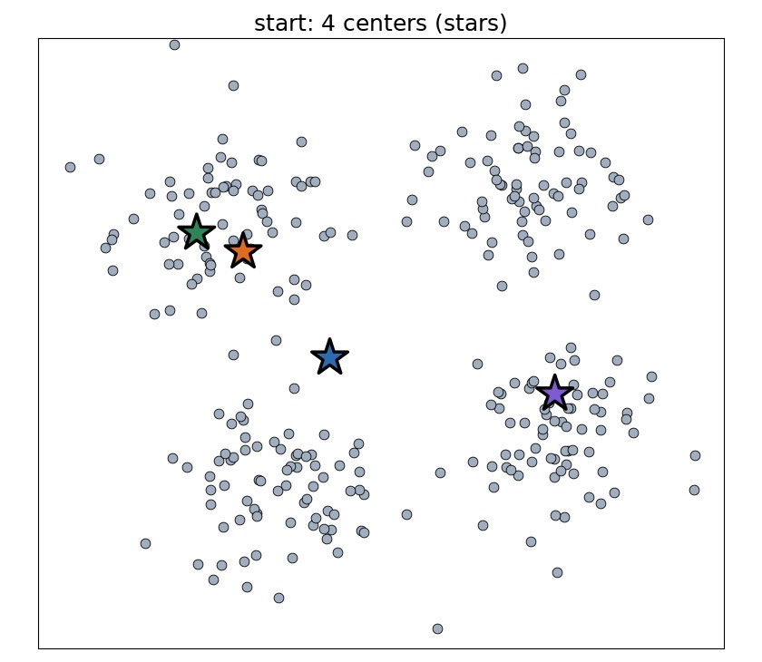

## Starting Centers Matter

- A bad start can **get stuck** in a bad result (top left: two blobs share one center; white stars: starting centers; colored stars: final centers).
- **Compactness:** sum of squared distances from each point to its center. Lower is better.
- **Several attempts:** run from different starts; keep the lowest compactness.
- **k-means++:** first center at random; each next center **far from the chosen ones**.

[figure not shown]

## Color Segmentation with k-Means

- Each pixel is a point $(R,G,B)$ in 3D color space.
- k-means with $k$ clusters groups the pixels into $k$ groups, each represented by a color (the center).
- Pixels of similar color land in one cluster, even on different objects.
- No labels needed: the colors group by themselves.

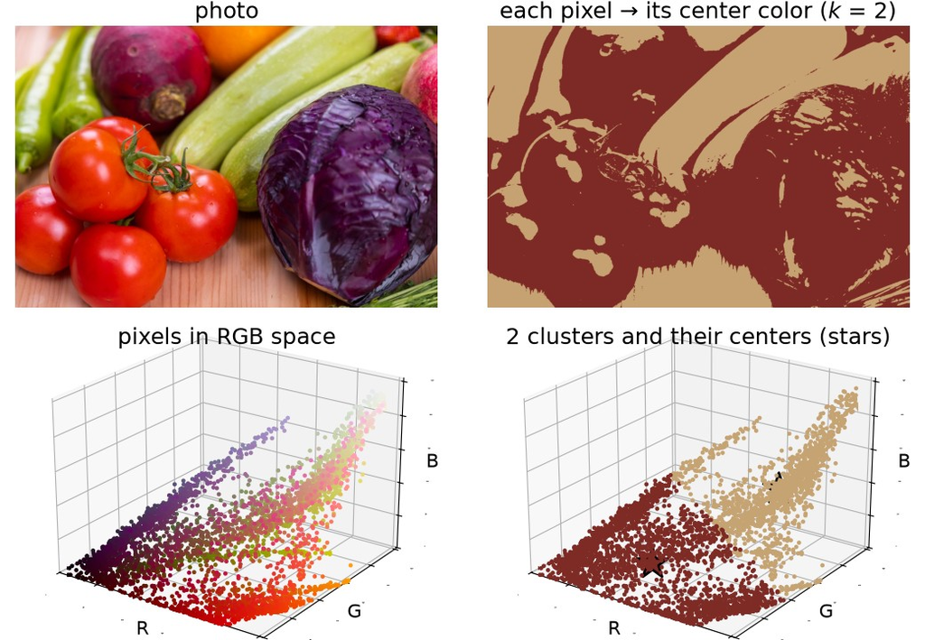

## k-Means in Code

- `cv2.kmeans(data, K, bestLabels, criteria, attempts, flags)`:
  - `data`: one point per row (`float32`).
  - `K`: the number of clusters $k$.
  - `bestLabels`: starting labels (`None`: not given).
  - `criteria`: stop after 20 rounds or when the centers move < 1.0.
  - `attempts`: 5 runs from different starts; keep the lowest compactness.
  - `flags`: starting centers. `KMEANS_PP_CENTERS`: k-means++; `KMEANS_RANDOM_CENTERS`: random points.
- Returns `compactness`, `labels` (cluster of each point), `centers` ($k$ × 3).
- `centers[labels]`: each pixel → its center color.

```python
import cv2
import numpy as np

image = cv2.imread("fruits.jpg")        # H x W x 3 (BGR)
pixels = image.reshape(-1, 3).astype(np.float32)

stop = cv2.TERM_CRITERIA_EPS + cv2.TERM_CRITERIA_MAX_ITER
criteria = (stop, 20, 1.0)   # 20 rounds or moves < 1.0
compactness, labels, centers = cv2.kmeans(
    pixels, 4, None, criteria, 5, cv2.KMEANS_PP_CENTERS)

segmented = centers[labels.ravel()].reshape(image.shape)
cv2.imwrite("fruits_k4.png", segmented.astype(np.uint8))
```

## PCA: The Directions of Largest Variance

- **PCA** (principal component analysis): find the directions in which the data varies the most.

**PCA**

1. Subtract the mean from every point.
2. **First component** $\mathbf{u}_1$: the direction of largest variance.
3. **Next components** $\mathbf{u}_2, \mathbf{u}_3, \dots$: largest remaining variance, perpendicular to the previous ones.
4. Keep the first $k$. Describe each point by its $k$ coordinates along them.
- The components are the **eigenvectors** of the data’s **covariance matrix**.

[figure not shown]

$\mathbf{u}_1$ holds **93%** of the variance. Keep only the coordinate along $\mathbf{u}_1$: 1 number instead of 2, and the points barely move.

## PCA on FashionMNIST

- PCA of the 50,000 training images, each a vector of 784 numbers.
- Mean image $\boldsymbol{\mu}$ and components $\mathbf{u}_j$ are 784-vectors too: show them as images.
- Red: add ink to the mean. Blue: remove ink. Early components: coarse shapes. Later: finer details.
- Variance kept: 72% with 10 components, 86% with 50. **187** of the 784 components keep 95%.

[figure not shown]

## Reconstruction with k Components

- Any image is the mean plus a weighted sum of components:

$$\bbox[border: 2px solid #c53030; padding: 2px 6px]{\hat{\mathbf{x}} = \boldsymbol{\mu} + a_1 \mathbf{u}_1 + \dots + a_k \mathbf{u}_k}\;\;{\color{#c53030}{\begin{array}{l}\textbf{PCA}\\ \textbf{reconstruction}\end{array}}}$$

- $\boldsymbol{\mu}$: mean image; $\mathbf{u}_j$: component $j$.
- $a_j = \mathbf{u}_j \cdot (\mathbf{x} - \boldsymbol{\mu})$: coordinate of image $\mathbf{x}$ along $\mathbf{u}_j$.
- With $k$ = 50 numbers instead of 784, the garment is still easy to recognize.
- So the coordinates $(a_1, \dots, a_k)$ are compact **features**: an input for a classifier.

[figure not shown]

## PCA Features for Recognition

[figure not shown]

- **Left:** PCA uses no labels, yet with 2 numbers per image many classes form their own regions; look-alike classes overlap.
- **Right:** 20 features: within 1 point of the 784 pixels (84.4% vs. 85.0%). From 50 on, slightly better (the small components are mostly pixel noise).
- Still pixel-based: a 2-pixel shift drops KNN on 50 PCA features to 66.0%.

## PCA in Code

- `PCACompute(data, mean, maxComponents)`: `data` has one image per row. `mean=None`: compute the mean. Returns the mean $\boldsymbol{\mu}$ (1 × 784) and the components $\mathbf{u}_j$ (one per row: 50 × 784).
- `PCAProject(X, mean, vecs)`: the coordinates $a_1, \dots, a_k$ of each row of `X`.
- `PCABackProject(A, mean, vecs)`: the reconstructions $\boldsymbol{\mu} + a_1 \mathbf{u}_1 + \dots + a_k \mathbf{u}_k$.
- **KNN on PCA features** ($k$ = 6 neighbors, test set):

| Input | Numbers | Accuracy | Time / image |
| --- | --- | --- | --- |
| pixels | 784 | 85.0% | 1.4 ms |
| PCA | 50 | 85.6% | 0.1 ms |

```python
import cv2
import numpy as np

# X_tr: (50000, 784), X_te: (10000, 784) float32
mu, U = cv2.PCACompute(X_tr, mean=None, maxComponents=50)
F_tr = cv2.PCAProject(X_tr, mu, U)     # (50000, 50)
F_te = cv2.PCAProject(X_te, mu, U)     # (10000, 50)

X_hat = cv2.PCABackProject(F_te, mu, U)    # (10000, 784)
print("MSE:", np.mean((X_hat - X_te) ** 2))

# Any classifier can use the features, e.g., KNN:
knn = cv2.ml.KNearest_create()
knn.train(F_tr, cv2.ml.ROW_SAMPLE, y_tr.astype(np.float32))
_, pred, _, _ = knn.findNearest(F_te, k=best_k)
```

# Supervised Learning: SVM

## Linear Classifiers

- A **linear classifier** scores an input with a weighted sum:

$$\bbox[border: 2px solid #c53030; padding: 2px 6px]{f(\mathbf{x}) = \mathbf{w} \cdot \mathbf{x} + b}\;\;{\color{#c53030}{\begin{array}{l}\textbf{linear}\\ \textbf{classifier}\end{array}}}$$

- $\mathbf{x}$: input point coordinates.
- $\mathbf{w}$: weights; $b$: bias. Both learned.
- Predict orange if $f(\mathbf{x}) > 0$, blue otherwise.
- The **decision boundary** $f(\mathbf{x}) = 0$ is a line (a “hyperplane” in more dimensions).
- Many lines separate the training points (dashed). **Which one is best?**

[figure not shown]

## Support Vector Machine (SVM)

- **SVM** (support vector machine): the linear classifier with the **largest margin**. A wide gap is safer for new points.
- **Margin:** the distance from the boundary to the closest training points.
- **Support vectors:** the points on or inside the margin. They alone fix the boundary; moving any other point changes nothing.

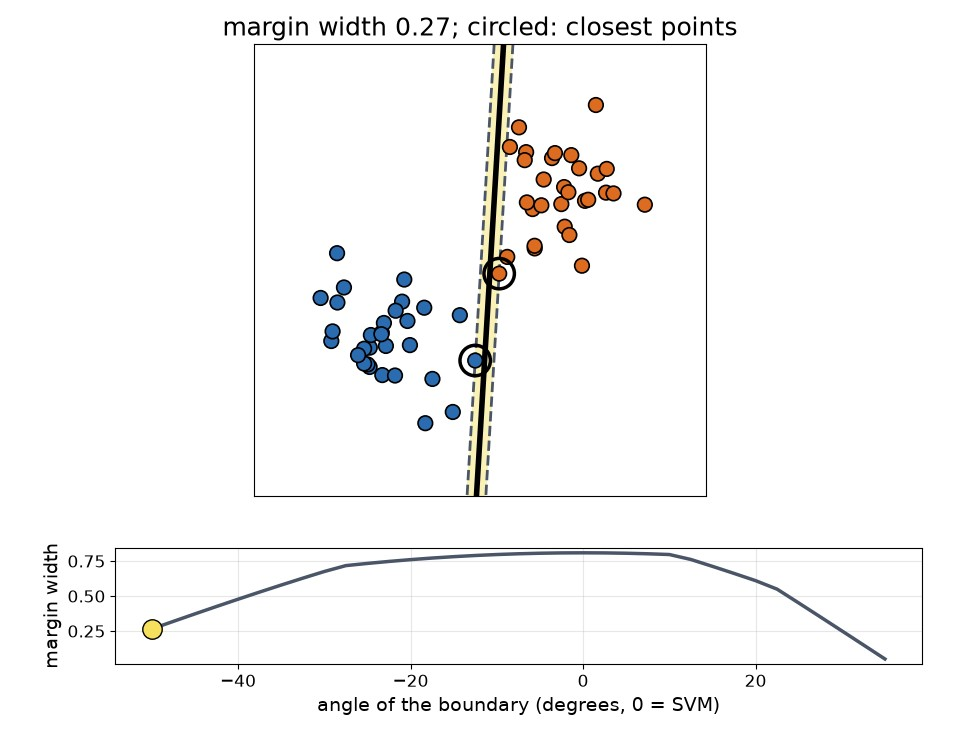

## Soft Margin

- Overlapping classes: some points must be inside the margin or on the wrong side (**soft margin**).
- Hyperparameter $C$: the penalty for those points.
  - Small $C$: wide margin, many points inside.
  - Large $C$: narrow margin, fewer points inside.
- Like $k$, choose $C$ on validation data.

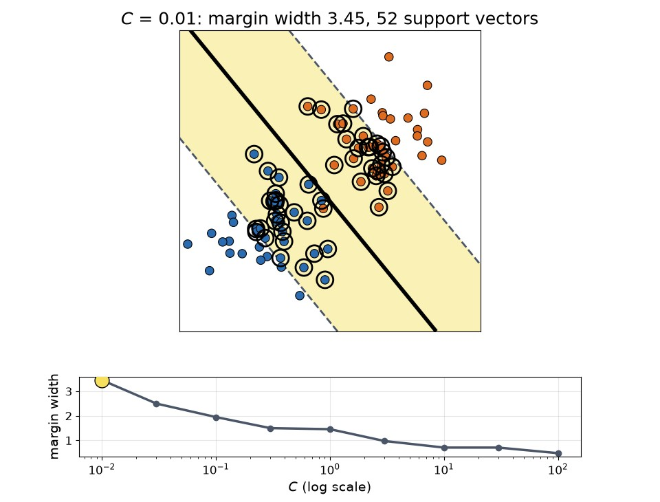

## Kernel SVM: Nonlinear Boundaries

- No line separates blue and orange points.
- Idea: **map** each point to a higher-dimensional space, where a **plane** separates them. Here: $(x_1,\, x_2) \mapsto (x_1,\, x_2,\, x_1^2 + x_2^2)$.
- A linear SVM in the new space is a nonlinear boundary in the original space (here: a circle).
- In practice, a **kernel** (e.g., **RBF**) builds the mapping inside the SVM; its hyperparameter $\gamma$ sets how curvy the boundary can be.

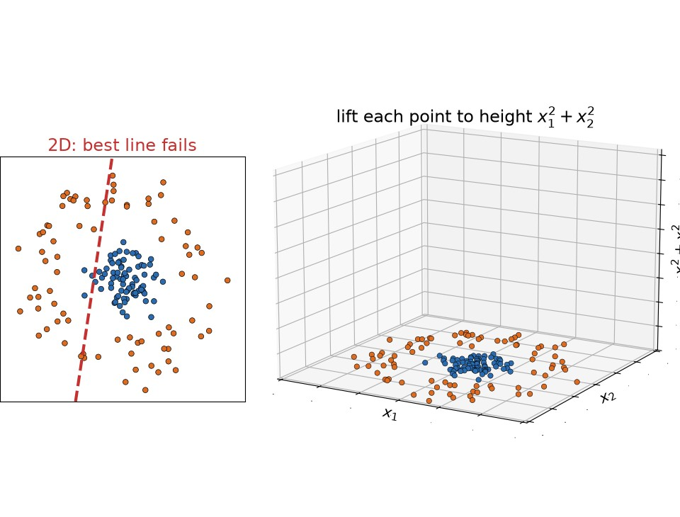

## Multi-Class SVM: One vs. Rest

- Unfortunately, there is no definitive multi-class SVM. In practice, we combine multiple two-class SVMs.

**One vs. Rest**

1. For each class $c$: train a binary SVM, class $c$ (+1) vs. all other classes (−1).
2. New image: compute all class scores $f_c(\mathbf{x})$.
3. Predict the class with the **highest score**.
- 3 classes: 3 SVMs. 10 FashionMNIST classes: 10 binary SVMs.
- Star: $f_{\text{blue}}$ = -1.21, $f_{\text{orange}}$ = -0.69, $f_{\text{purple}}$ = -1.38 $\rightarrow$ predict **orange**.

[figure not shown]

## Multi-Class SVM: One vs. One

**One vs. One**

1. For each pair of classes: train a binary SVM on the points of those two classes only.
2. New image: each SVM votes for one of its two classes.
3. Predict the class with the **most votes**.
- Star: votes 1 blue, 2 orange, 0 purple $\rightarrow$ predict **orange**.
- OpenCV’s SVM handles multiple classes by itself, with **one vs. one**: one SVM per pair of classes, 45 SVMs for 10 classes, then a majority vote.

|  | One vs. rest | One vs. one |
| --- | --- | --- |
| SVMs for 3 classes | 3 | 3 |
| SVMs for 10 classes | 10 | 45 |
| Data per SVM | all images | images of 2 classes |
| Prediction | highest score | most votes |

[figure not shown]

## SVM in Code

- `setType(SVM_C_SVC)`: classification with a soft margin.
- `setKernel(SVM_RBF)`, `setC(...)`, `setGamma(...)`: kernel and hyperparameters.
- `train(F, ROW_SAMPLE, y)`: `F` one feature vector per row (`float32`); `y` labels (`int32`).
- `predict(F)`: predicted labels.
- Choose $C$ and $\gamma$ on the validation set (training on 10,000 images to save time). Validation accuracy:

|  | $\gamma$ = 0.01 | $\gamma$ = 0.03 | $\gamma$ = 0.1 |
| --- | --- | --- | --- |
| $C$ = 1 | 84.3% | 85.8% | 86.1% |
| $C$ = 10 | 86.4% | **86.9%** | 86.3% |
| $C$ = 100 | 86.7% | 85.9% | 86.2% |

- Final model on all 50,000 training images: test accuracy **88.9%**, trained in 17 s.

```python
import cv2
import numpy as np

# F_tr, F_te: PCA features (50 per image), scaled
svm = cv2.ml.SVM_create()
svm.setType(cv2.ml.SVM_C_SVC)
svm.setKernel(cv2.ml.SVM_RBF)
svm.setC(best_C)          # chosen on validation data
svm.setGamma(best_gamma)
svm.train(F_tr, cv2.ml.ROW_SAMPLE, y_tr.astype(np.int32))
# 10 classes: OpenCV trains 45 one-vs-one SVMs inside

_, pred = svm.predict(F_te)
print("test accuracy:", np.mean(pred.ravel() == y_te))
```

## PCA + SVM: Full Code

```python
import gzip
import time
from pathlib import Path

import cv2
import numpy as np

# 1. Data: FashionMNIST as 784-vectors. Split 50,000 training / 10,000 validation; 10,000 test.
data_dir = Path("assets/datasets/fashion_mnist")    # folder with the four .gz files

def read_idx(name, offset):
    with gzip.open(data_dir / name) as f:
        return np.frombuffer(f.read(), np.uint8, offset=offset)

X = read_idx("train-images-idx3-ubyte.gz", 16).reshape(-1, 784).astype(np.float32)
y = read_idx("train-labels-idx1-ubyte.gz", 8).astype(np.int32)
X_te = read_idx("t10k-images-idx3-ubyte.gz", 16).reshape(-1, 784).astype(np.float32)
y_te = read_idx("t10k-labels-idx1-ubyte.gz", 8).astype(np.int32)
X_tr, y_tr, X_val, y_val = X[:50000], y[:50000], X[50000:], y[50000:]

# 2. PCA features (learned on the training set only), scaled to unit spread.
mu, U = cv2.PCACompute(X_tr, mean=None, maxComponents=50)
F_tr = cv2.PCAProject(X_tr, mu, U)
scale = F_tr.std()
F_tr = F_tr / scale
F_val = cv2.PCAProject(X_val, mu, U) / scale
F_te = cv2.PCAProject(X_te, mu, U) / scale

def train_svm(F, y, C, gamma):
    svm = cv2.ml.SVM_create()
    svm.setType(cv2.ml.SVM_C_SVC)
    svm.setKernel(cv2.ml.SVM_RBF)
    svm.setC(C)
    svm.setGamma(gamma)
    svm.setTermCriteria((cv2.TERM_CRITERIA_MAX_ITER + cv2.TERM_CRITERIA_EPS, 10000, 1e-3))
    svm.train(F, cv2.ml.ROW_SAMPLE, y)    # 10 classes: 45 one-vs-one SVMs inside
    return svm

def accuracy(svm, F, y):
    return np.mean(svm.predict(F)[1].ravel() == y)

# 3. Choose C and gamma on the validation set (train on 10,000 images to save time).
best_acc, best_C, best_gamma = 0, None, None
for C in [1, 10, 100]:
    for gamma in [0.01, 0.03, 0.1]:
        acc = accuracy(train_svm(F_tr[:10000], y_tr[:10000], C, gamma), F_val, y_val)
        print(f"C = {C}, gamma = {gamma}: validation accuracy = {acc:.3f}")
        if acc > best_acc:
            best_acc, best_C, best_gamma = acc, C, gamma

# 4. Final model on all training images; test accuracy, once.
t0 = time.perf_counter()
svm = train_svm(F_tr, y_tr, best_C, best_gamma)
print(f"trained in {time.perf_counter() - t0:.0f} s")
print(f"C = {best_C}, gamma = {best_gamma}: test accuracy = {accuracy(svm, F_te, y_te):.3f}")
```

## Our FashionMNIST Benchmark

| Method | Input | Test accuracy | Training time | Time per image | Model size |
| --- | --- | --- | --- | --- | --- |
| KNN ($k$ = 6) | 784 pixels | 85.0% | none | 1.4 ms | 157 MB |
| KNN ($k$ = 6) | 50 PCA features | 85.6% | PCA only | 0.1 ms | 10 MB |
| SVM (RBF) | 50 PCA features | **88.9%** | 16.5 s | 0.1 ms | 3.1 MB |

- SVM: best so far, **+3.9 points** over KNN on pixels.
- All three methods use pixel-based features. Neural networks learn their own features; we will compare them later.

[figure not shown]

## Key Takeaways

- **Recognition tasks** differ in their output: a label per image (classification), a box per object (detection), a label per pixel (segmentation).
- **Supervised** learning uses images and labels; **unsupervised** uses images only.
- Training error is not the goal: a model that is **too simple underfits**, one that is **too flexible overfits**. Fit **parameters** on the training set, choose **hyperparameters** on the validation set, and report the **test** error once.
- Pick the **metric for the task**. With imbalanced classes, accuracy alone misleads.
- **KNN** predicts the majority label of the $k$ nearest training images. It is simple, but **slow**, and pixel distance is **not semantic**.
- **k-means** groups unlabeled points into $k$ clusters. **PCA** finds the directions of largest variance and gives compact **features**.
- The **SVM** picks the boundary with the **largest margin**. $C$ trades margin width for training mistakes; kernels give nonlinear boundaries.
- All these methods use **pixel-based features**; neural networks learn their own features.